# Diabetes Readmission Prediction

Vivian Do, Bethany Wang

2023-06-24

### 1. Initial Data Preparation

#### **1.1 Import and check the Data**

```r
#Read in data, replace "?" with NA values
df <- read.csv(file = "diabetic_data.csv", na.strings=c("?"))
dim(df)
```

```
## [1] 101766     50
```

```r
str(df)
```

```
## 'data.frame':    101766 obs. of  50 variables:
##  $ encounter_id            : int  2278392 149190 64410 500364 16680 35754 55842 63768 12522 15738 ...
##  $ patient_nbr             : int  8222157 55629189 86047875 82442376 42519267 82637451 84259809 114882984 48330783 63555939 ...
##  $ race                    : chr  "Caucasian" "Caucasian" "AfricanAmerican" "Caucasian" ...
##  $ gender                  : chr  "Female" "Female" "Female" "Male" ...
##  $ age                     : chr  "[0-10)" "[10-20)" "[20-30)" "[30-40)" ...
##  $ weight                  : chr  NA NA NA NA ...
##  $ admission_type_id       : int  6 1 1 1 1 2 3 1 2 3 ...
##  $ discharge_disposition_id: int  25 1 1 1 1 1 1 1 1 3 ...
##  $ admission_source_id     : int  1 7 7 7 7 2 2 7 4 4 ...
##  $ time_in_hospital        : int  1 3 2 2 1 3 4 5 13 12 ...
##  $ payer_code              : chr  NA NA NA NA ...
##  $ medical_specialty       : chr  "Pediatrics-Endocrinology" NA NA NA ...
##  $ num_lab_procedures      : int  41 59 11 44 51 31 70 73 68 33 ...
##  $ num_procedures          : int  0 0 5 1 0 6 1 0 2 3 ...
```

[output cut: 36 more lines]

- There are 101766 data records with 50 features

#### **1.2 Filter out Irrelevant Observations**

- All patient encounters associated with a discharge to hospice or death will be removed, as the chance of readmission is low-impossible.

```r
dischargedRemoved <- c(11,13,14,19,20,21)
df <- subset(df, !(discharge_disposition_id %in% dischargedRemoved))
```

- encounter_id and patient_nbr are identifiers, not useful features. Payer_code is irrelevant feature too. They will be removed.

```r
df <- subset(df, select = -c(encounter_id, patient_nbr, payer_code))
dim(df)
```

```
## [1] 99343    47
```

#### **1.3 Filter out degenerated features**

```r
library(caret)

# Use nearZeroVar function to filter out low variance features
degenerateCols <- nearZeroVar(df)
length(degenerateCols)
```

```
## [1] 18
```

```r
degenerateColNames <- colnames(df[degenerateCols])
degenerateColNum <- length(degenerateColNames)

cat("These are ", degenerateColNum, " degenerated predictors:\n", degenerateColNames, "\n\n")
```

```
## These are  18  degenerated predictors:
##  max_glu_serum repaglinide nateglinide chlorpropamide glimepiride acetohexamide tolbutamide acarbose miglitol troglitazone tolazamide examide citoglipton glyburide.metformin glipizide.metformin glimepiride.pioglitazone metformin.rosiglitazone metformin.pioglitazone
```

```r
df<- df[, -degenerateCols]
dim(df)
```

```
## [1] 99343    29
```

```r
colnames(df)
```

```
##  [1] "race"                     "gender"
##  [3] "age"                      "weight"
##  [5] "admission_type_id"        "discharge_disposition_id"
##  [7] "admission_source_id"      "time_in_hospital"
##  [9] "medical_specialty"        "num_lab_procedures"
## [11] "num_procedures"           "num_medications"
## [13] "number_outpatient"        "number_emergency"
## [15] "number_inpatient"         "diag_1"
## [17] "diag_2"                   "diag_3"
## [19] "number_diagnoses"         "A1Cresult"
## [21] "metformin"                "glipizide"
## [23] "glyburide"                "pioglitazone"
## [25] "rosiglitazone"            "insulin"
## [27] "change"                   "diabetesMed"
## [29] "readmitted"
```

- 18 degenerated predictors that show near-zero variance have been removed. 29 columns are left in the dataset.

#### **1.4 Filter out categorical levels indicating nulls**

‘discharge_disposition_id’ (discharge ID), ‘admission_type_id’ (admission type ID), and ‘admission_source_id’ (admission source ID) are categorical variables with levels identified by their ID number. For example, ‘admission_type_id’ 1 refers to ‘Emergency’.

For admission source and type, the following ID levels associated with null values will be replaced as NA:

- Admission source ID 9 (Not Available), 17 (NULL), and 20 (Not Mapped)
- Admission type ID 6 (NULL) and 8 (Not Mapped)

```r
admissionsourceRemoved <- c(9,17,20)
df$admission_source_id[df$admission_source_id %in% admissionsourceRemoved] <- NA

admissiontypeRemoved <- c(6,8)
df$admission_type_id[df$admission_type_id %in% admissiontypeRemoved] <- NA
table(df$admission_source_id)
```

```
##
##     1     2     3     4     5     6     7     8    10    11    13    14    22
## 29168  1081   185  3118   806  2239 55850    15     8     2     1     2    12
##    25
##     2
```

```r
sum(is.na(df$admission_source_id))
```

```
## [1] 6854
```

#### **1.5 Handle missing values**

- Check missing values

```r
# Check null values
#Show null counts
null_counts <- sort(colSums(is.na(df)), decreasing=TRUE)
head(null_counts,10)
```

```
##              weight   medical_specialty admission_source_id   admission_type_id
##               96218               48616                6854                5527
##                race              diag_3              diag_2              diag_1
##                2234                1419                 356                  20
##              gender                 age
##                   0                   0
```

```r
#Show proportion of null counts
nullProp <- sort(round(colMeans(is.na(df)),3), decreasing=TRUE)
head(nullProp,10)
```

```
##                   weight        medical_specialty      admission_source_id
##                    0.969                    0.489                    0.069
##        admission_type_id                     race                   diag_3
##                    0.056                    0.022                    0.014
##                   diag_2                   gender                      age
##                    0.004                    0.000                    0.000
## discharge_disposition_id
##                    0.000
```

```r
# remove weight and medical_specialty
df<- subset(df, select = -c(weight, medical_specialty))

# Remove other null values
df <- na.omit(df)

null_counts <- sort(colSums(is.na(df)), decreasing=TRUE)
head(null_counts,10)
```

```
##                     race                   gender                      age
##                        0                        0                        0
##        admission_type_id discharge_disposition_id      admission_source_id
##                        0                        0                        0
##         time_in_hospital       num_lab_procedures           num_procedures
##                        0                        0                        0
##          num_medications
##                        0
```

```r
dim(df)
```

```
## [1] 86566    27
```

#### **1.6 Feature Creation**

- Explore primary diagnoses (‘diag_1’) and secondary diagnoses (‘diag_2’, ‘diag_3’)

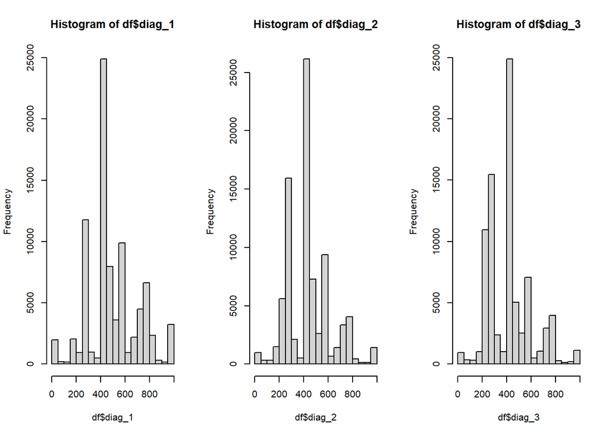

```r
# Convert to numeric
df$diag_1 <- as.numeric(df$diag_1)
df$diag_2 <- as.numeric(df$diag_2)
df$diag_3 <- as.numeric(df$diag_3)

# Show distributions of diagnoses
par(mfrow=c(1,3))
hist(df$diag_1)
hist(df$diag_2)
hist(df$diag_3)
```

```r
#summary(df$diag_1)
```

- Extract primary/secondary diagnoses

```r
library(dplyr)

df <- df %>%
  mutate(primary_diagnosis = case_when(
    substr(diag_1, 1, 3) == "250" ~ "Diabetes",
    #between(as.numeric(diag_1), 001, 139) ~ "Infectious and Parasitic Diseases",
    between(as.numeric(diag_1), 140, 239) ~ "Neoplasms",
    between(as.numeric(diag_1), 320, 459) ~ "Circulatory",
    between(as.numeric(diag_1), 460, 519) ~ "Respiratory",
    between(as.numeric(diag_1), 520, 579) ~ "Digestive",
    between(as.numeric(diag_1), 580, 629) ~ "Genitourinary System",
    #between(as.numeric(diag_1), 680, 709) ~ "Skin/Subcutaneous Tissue",
    between(as.numeric(diag_1), 710, 739) ~ "Musculoskeletal",
    between(as.numeric(diag_1), 760, 779) ~ "Perinatal",
    between(as.numeric(diag_1), 800, 999) ~ "Injury and Poisoning",
    TRUE ~ "Other"
  ))

# Secondary Diagnosis
df <- df %>%
  mutate(secondary_diagnosis = case_when(
    substr(diag_2, 1, 3) == "250" ~ "Diabetes",
    #between(as.numeric(diag_2), 001, 139) ~ "Infectious and Parasitic Diseases",
    between(as.numeric(diag_2), 140, 239) ~ "Neoplasms",
    between(as.numeric(diag_2), 320, 459) ~ "Circulatory",
    between(as.numeric(diag_2), 460, 519) ~ "Respiratory",
    between(as.numeric(diag_2), 520, 579) ~ "Digestive",
    between(as.numeric(diag_2), 580, 629) ~ "Genitourinary System",
    #between(as.numeric(diag_2), 680, 709) ~ "Skin/Subcutaneous Tissue",
    between(as.numeric(diag_2), 710, 739) ~ "Musculoskeletal",
    between(as.numeric(diag_2), 760, 779) ~ "Perinatal",
    between(as.numeric(diag_2), 800, 999) ~ "Injury and Poisoning",
    TRUE ~ "Other"
  ))

# Secondary Diagnosis
df <- df %>%
  mutate(secondary_diagnosis2 = case_when(
    substr(diag_3, 1, 3) == "250" ~ "Diabetes",
    #between(as.numeric(diag_3), 001, 139) ~ "Infectious and Parasitic Diseases",
    between(as.numeric(diag_3), 140, 239) ~ "Neoplasms",
    between(as.numeric(diag_3), 320, 459) ~ "Circulatory",
    between(as.numeric(diag_3), 460, 519) ~ "Respiratory",
    between(as.numeric(diag_3), 520, 579) ~ "Digestive",
    between(as.numeric(diag_3), 580, 629) ~ "Genitourinary System",
    #between(as.numeric(diag_3), 680, 709) ~ "Skin/Subcutaneous Tissue",
    between(as.numeric(diag_3), 710, 739) ~ "Musculoskeletal",
    between(as.numeric(diag_3), 760, 779) ~ "Perinatal",
    between(as.numeric(diag_3), 800, 999) ~ "Injury and Poisoning",
    TRUE ~ "Other"
  ))
df$primary_diagnosis <- as.factor(df$primary_diagnosis)
df$secondary_diagnosis <- as.factor(df$secondary_diagnosis)
df$secondary_diagnosis2 <- as.factor(df$secondary_diagnosis2)
```

- Show counts of diseases for the primary and secondary diagnosis:

```r
table(df$primary_diagnosis)
```

```
##
##          Circulatory             Diabetes            Digestive
##                27207                 7185                 7873
## Genitourinary System Injury and Poisoning      Musculoskeletal
##                 4445                 6017                 4217
##            Neoplasms                Other          Respiratory
##                 2762                18242                 8618
```

```r
# table(df$secondary_diagnosis)
# table(df$secondary_diagnosis2)
```

- All levels w/ less than 2500 instances are combined into ‘Other’
- Most common primary/secondary diagnosis were circulatory.
- 7185 patients had diabetes as their primary diagnosis
- diag_1, diag_2, and diag_3 are turned to new variables. They are not needed anymore and will be removed.

```r
df <- subset(df, select = -c(diag_1, diag_2,diag_3))
dim(df)
```

```
## [1] 86566    27
```

#### **1.7 Convert categorical variables into factors**

- All feature that are recorded as chr type are categorical variables
- admission_type_id, discharge_disposition_id, admission_source_id are recorded as int, but should be taken as categorical variables.

```r
#Convert categorical variables into factors (according to Table 1 https://www.hindawi.com/journals/bmri/2014/781670/tab1/)
df[sapply(df, is.character)] <- lapply(df[sapply(df, is.character)],
                                       as.factor)

df$admission_type_id <- as.factor(df$admission_type_id)
df$discharge_disposition_id <- as.factor(df$discharge_disposition_id)
df$admission_source_id <- as.factor(df$admission_source_id)
```

- All categorical variables have been converted into factors

#### **1.8 Classify features**

- 27 variables are left for further analysis.
- Subset numerical and categorical features

```r
# Subset numerical and categorical features into new data frames
library(dplyr)
df_num <- df %>%  select_if(is.integer)
df_cat <- df %>% select_if(is.factor)

# Show numerical variables
cat("These are the numerical features:\n", colnames(df_num), "\n\n")
```

```
## These are the numerical features:
##  time_in_hospital num_lab_procedures num_procedures num_medications number_outpatient number_emergency number_inpatient number_diagnoses
```

```r
# Show categorical variables
cat("These are the categorical features:\n", colnames(df_cat), "\n\n")
```

```
## These are the categorical features:
##  race gender age admission_type_id discharge_disposition_id admission_source_id A1Cresult metformin glipizide glyburide pioglitazone rosiglitazone insulin change diabetesMed readmitted primary_diagnosis secondary_diagnosis secondary_diagnosis2
```

#### **1.9 Explore and revalue the response variable**

- We use “readmitted” as our response variable

```r
# Show readmission counts
table(df$readmitted)
```

```
##
##   <30   >30    NO
##  9985 31109 45472
```

We will combine all patients who were admitted into one level. Thus, our response variable will be binary:

- YES if the patient was readmitted at any time
- NO if the patient was not readmitted

```r
library(plyr)

revalue(df$readmitted, c("<30" = "YES")) -> df$readmitted
revalue(df$readmitted, c(">30" = "YES")) -> df$readmitted

# Show readmission counts using binary levels
table(df$readmitted)
```

```
##
##   YES    NO
## 41094 45472
```

```r
# Show readmission ratio using binary levels
round(table(df$readmitted) / length(df$readmitted),2)
```

```
##
##  YES   NO
## 0.47 0.53
```

- The response variable now contains 47% of “YES” and 53% of “NO”.

### 2. Exploratory Data Analysis

#### **2.1 Statistics of the numerical variables**

```r
summary(df_num)
```

```
##  time_in_hospital num_lab_procedures num_procedures  num_medications
##  Min.   : 1.000   Min.   :  1.00     Min.   :0.000   Min.   : 1.00
##  1st Qu.: 2.000   1st Qu.: 33.00     1st Qu.:0.000   1st Qu.:10.00
##  Median : 4.000   Median : 44.00     Median :1.000   Median :15.00
##  Mean   : 4.413   Mean   : 43.42     Mean   :1.348   Mean   :16.06
##  3rd Qu.: 6.000   3rd Qu.: 57.00     3rd Qu.:2.000   3rd Qu.:20.00
##  Max.   :14.000   Max.   :132.00     Max.   :6.000   Max.   :81.00
##  number_outpatient number_emergency  number_inpatient  number_diagnoses
##  Min.   : 0.0000   Min.   : 0.0000   Min.   : 0.0000   Min.   : 3.000
##  1st Qu.: 0.0000   1st Qu.: 0.0000   1st Qu.: 0.0000   1st Qu.: 6.000
##  Median : 0.0000   Median : 0.0000   Median : 0.0000   Median : 9.000
##  Mean   : 0.3664   Mean   : 0.2017   Mean   : 0.6462   Mean   : 7.543
##  3rd Qu.: 0.0000   3rd Qu.: 0.0000   3rd Qu.: 1.0000   3rd Qu.: 9.000
##  Max.   :42.0000   Max.   :76.0000   Max.   :21.0000   Max.   :16.000
```

#### **2.2 Correlations of the numerical variables**

- Find Correlations of numerical features

```r
library(corrplot)
correlations <- round(cor(df_num), 2)
correlations
```

```
##                    time_in_hospital num_lab_procedures num_procedures
## time_in_hospital               1.00               0.33           0.19
## num_lab_procedures             0.33               1.00           0.03
## num_procedures                 0.19               0.03           1.00
## num_medications                0.46               0.27           0.38
## number_outpatient             -0.01               0.02          -0.02
## number_emergency              -0.01               0.01          -0.04
## number_inpatient               0.07               0.04          -0.07
## number_diagnoses               0.22               0.16           0.05
##                    num_medications number_outpatient number_emergency
## time_in_hospital              0.46             -0.01            -0.01
## num_lab_procedures            0.27              0.02             0.01
## num_procedures                0.38             -0.02            -0.04
## num_medications               1.00              0.05             0.01
## number_outpatient             0.05              1.00             0.09
## number_emergency              0.01              0.09             1.00
## number_inpatient              0.07              0.11             0.27
## number_diagnoses              0.24              0.10             0.05
##                    number_inpatient number_diagnoses
## time_in_hospital               0.07             0.22
## num_lab_procedures             0.04             0.16
## num_procedures                -0.07             0.05
## num_medications                0.07             0.24
## number_outpatient              0.11             0.10
## number_emergency               0.27             0.05
## number_inpatient               1.00             0.10
## number_diagnoses               0.10             1.00
```

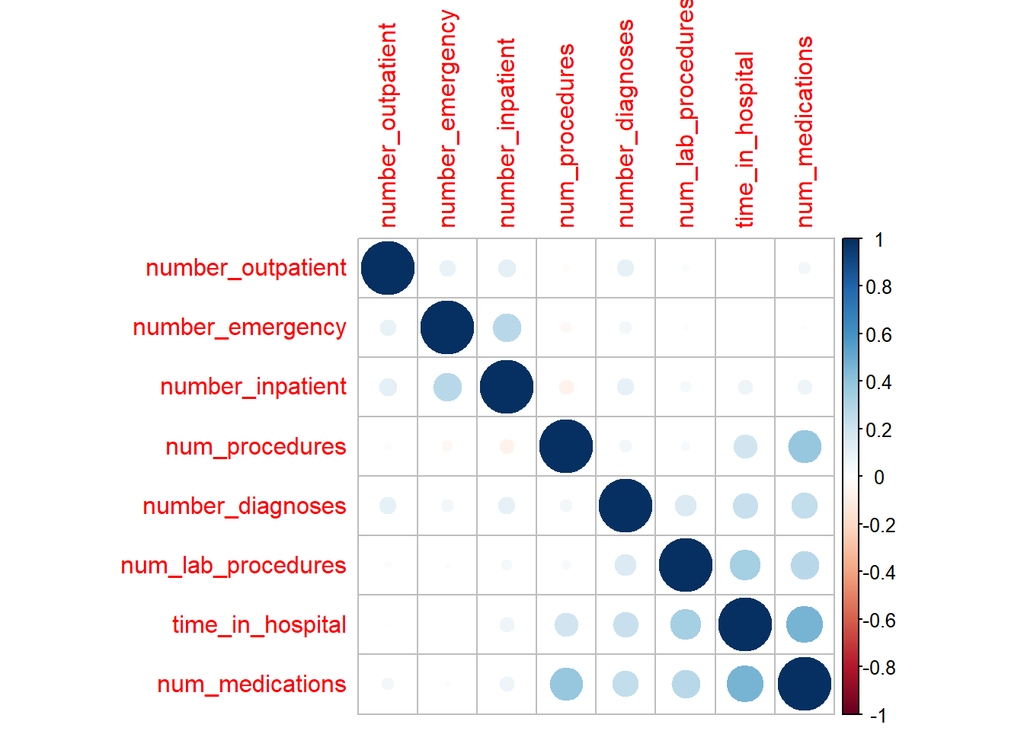

```r
# Correlation plot
corrplot(correlations, order = "hclust")
```

Other than that, there is no much correlations between other variables.

#### **2.3 Distribution of the numerical variables**

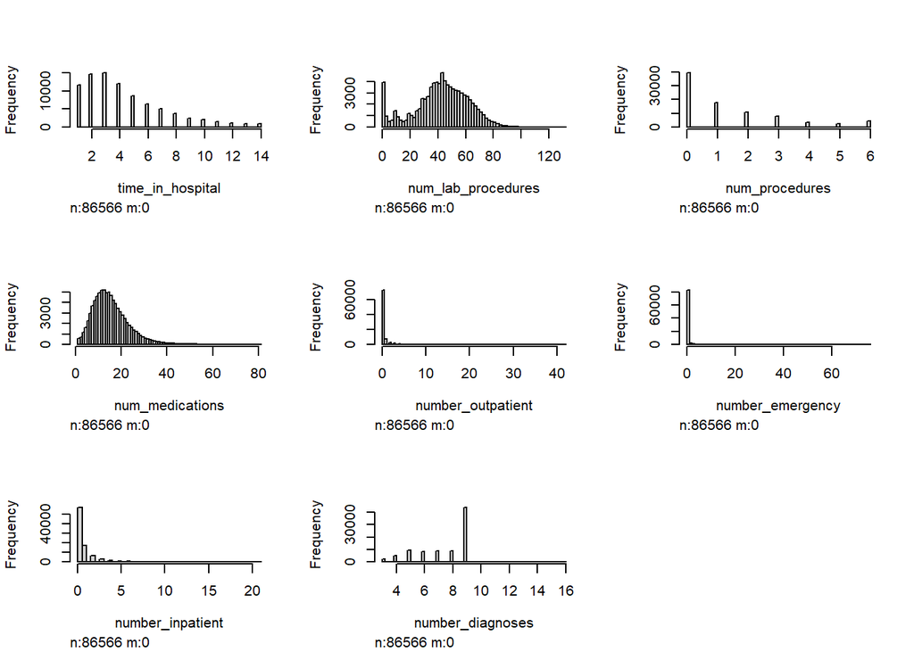

```r
library(Hmisc)
hist.data.frame(df_num)
```

- number_medications and number_lab_procedures have a distribution that is close to normal distribution. The distribution for other variables are all skewed.

#### **2.4 Explore the relationship between the numerical predictors and the predicted variable**

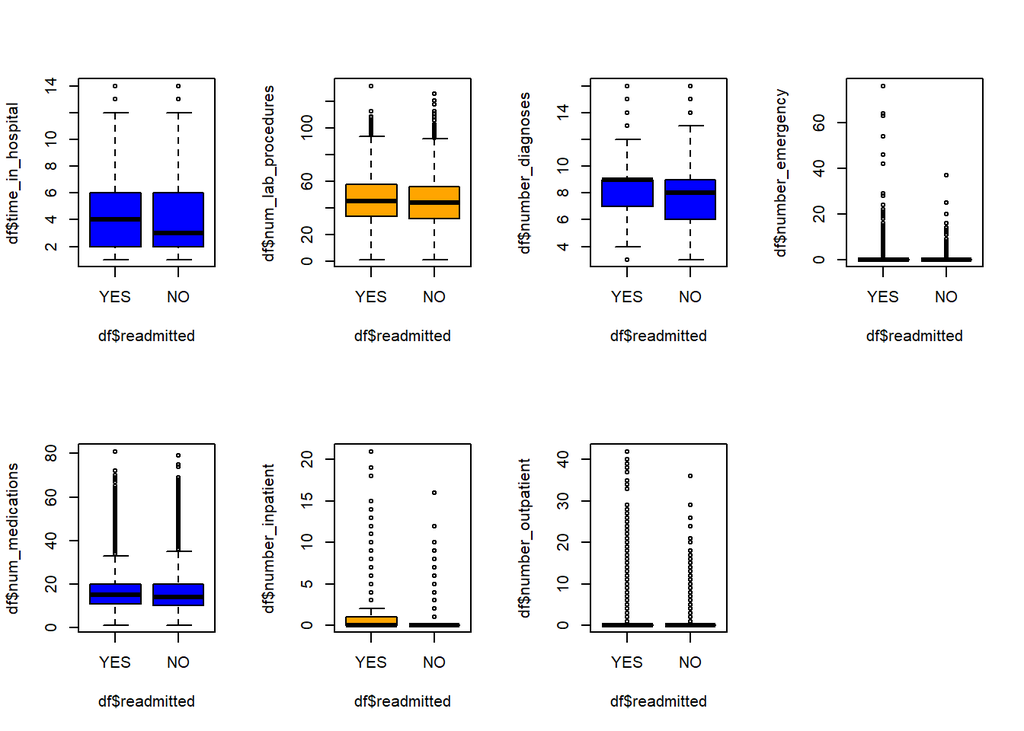

```r
par(mfrow = c(2,4))

boxplot(df$time_in_hospital ~ df$readmitted, col="blue")
boxplot(df$num_lab_procedures ~ df$readmitted, col="orange")
boxplot(df$number_diagnoses ~ df$readmitted, col="blue")

boxplot(df$number_emergency ~ df$readmitted, col="orange")
boxplot(df$num_medications ~ df$readmitted, col="blue")
boxplot(df$number_inpatient ~ df$readmitted, col="orange")
boxplot(df$number_outpatient ~ df$readmitted, col="blue")
```

Patients who are readmitted, in general:

- Spend more time in the hospital
- Have more lab procedures done

#### **2.5 Distribution of the categorical variables**

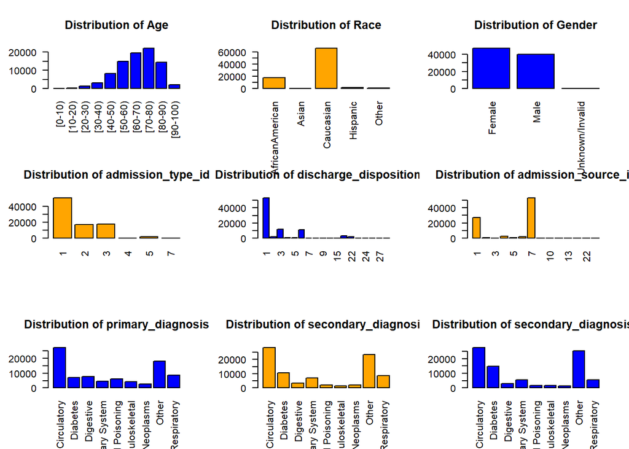

```r
par(mfrow = c(3,3))

barplot(table(df$age), main="Distribution of Age", col="blue", las=2)
barplot(table(df$race), main="Distribution of Race", col="orange", las=2)
barplot(table(df$gender), main="Distribution of Gender", col="blue", las=2)

barplot(table(df$admission_type_id), main="Distribution of admission_type_id",
        col="orange", las=2)
barplot(table(df$discharge_disposition_id), main="Distribution of discharge_disposition_id",
        col="blue", las=2)
barplot(table(df$admission_source_id), main="Distribution of admission_source_id",
        col="orange",las=2)


barplot(table(df$primary_diagnosis), main="Distribution of primary_diagnosis",
        col="blue", las=2)
barplot(table(df$secondary_diagnosis), main="Distribution of secondary_diagnosis",
        col="orange", las=2)
barplot(table(df$secondary_diagnosis2), main="Distribution of secondary_diagnosis2",
        col="blue", las=2)
```

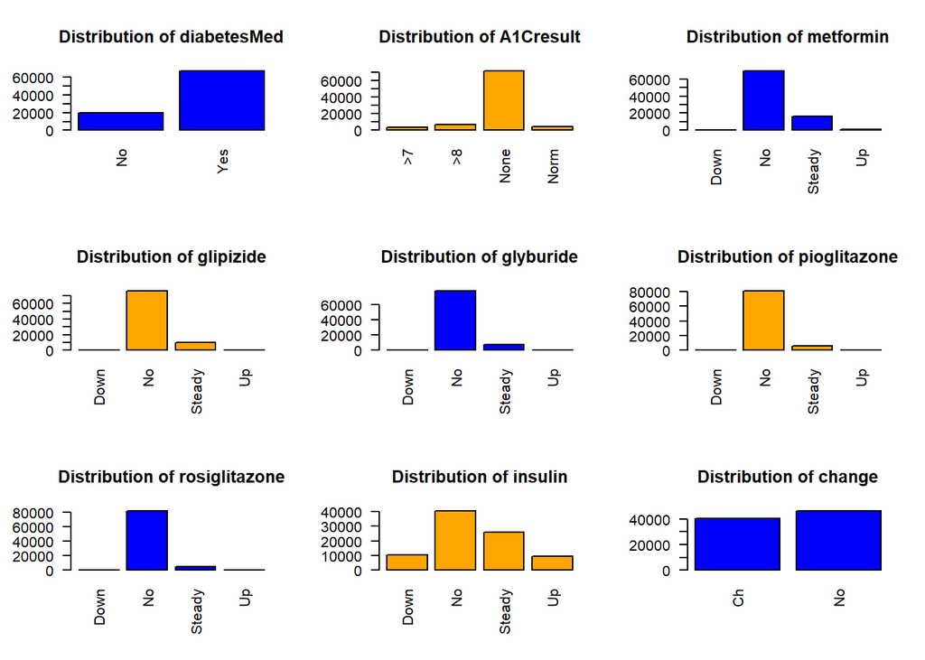

```r
par(mfrow = c(3,3))

barplot(table(df$diabetesMed), main="Distribution of diabetesMed", col="blue", las=2)
barplot(table(df$A1Cresult), main="Distribution of A1Cresult", col="orange", las=2)
barplot(table(df$metformin), main="Distribution of metformin", col="blue", las=2)


barplot(table(df$glipizide), main="Distribution of glipizide", col="orange", las=2)
barplot(table(df$glyburide), main="Distribution of glyburide", col="blue", las=2)
barplot(table(df$pioglitazone), main="Distribution of pioglitazone", col="orange", las=2)


barplot(table(df$rosiglitazone), main="Distribution of rosiglitazone", col="blue", las=2)
barplot(table(df$insulin), main="Distribution of insulin", col="orange", las=2)
barplot(table(df$change), main="Distribution of change", col="blue", las=2)
```

#### **2.6 Explore the relationship between the categorical predictors and the predicted variable**

```r
# Frequency counts
ct_race <- table(df$readmitted, df$race)
ct_gender <- table(df$readmitted, df$gender)
ct_age <- table(df$readmitted, df$age)
ct_admissionType <- table(df$readmitted, df$admission_type_id)
ct_dischargeID <- table(df$readmitted, df$discharge_disposition_id)
ct_admissionSource <- table(df$readmitted, df$admission_source_id)
ct_A1C <- table(df$readmitted, df$A1Cresult)
ct_metf <- table(df$readmitted, df$metformin)
ct_glipz <- table(df$readmitted, df$glipizide)
ct_glyb <- table(df$readmitted, df$glyburide)
ct_piog <- table(df$readmitted, df$pioglitazone)
ct_rosig <- table(df$readmitted, df$rosiglitazone)
ct_insulin <- table(df$readmitted, df$insulin)
ct_change <- table(df$readmitted, df$change)
ct_diabMeds <- table(df$readmitted, df$diabetesMed)

# Create contingency tables showing proportions
ct_race1 <- prop.table(table(df$readmitted, df$race),2)
ct_gender1 <- prop.table(table(df$readmitted, df$gender),2)
ct_age1 <- prop.table(table(df$readmitted, df$age),2)
ct_admissionType1 <- prop.table(table(df$readmitted, df$admission_type_id),2)
ct_dischargeID1 <- prop.table(table(df$readmitted, df$discharge_disposition_id),2)
ct_admissionSource1 <- prop.table(table(df$readmitted, df$admission_source_id),2)
ct_A1C1 <- prop.table(table(df$readmitted, df$A1Cresult),2)
ct_metf1 <- prop.table(table(df$readmitted, df$metformin),2)
ct_glipz1 <- prop.table(table(df$readmitted, df$glipizide),2)
ct_glyb1 <- prop.table(table(df$readmitted, df$glyburide),2)
ct_piog1 <- prop.table(table(df$readmitted, df$pioglitazone),2)
ct_rosig1 <- prop.table(table(df$readmitted, df$rosiglitazone),2)
ct_insulin1 <- prop.table(table(df$readmitted, df$insulin),2)
ct_change1 <- prop.table(table(df$readmitted, df$change),2)
ct_diabMeds1 <- prop.table(table(df$readmitted, df$diabetesMed),2)
```

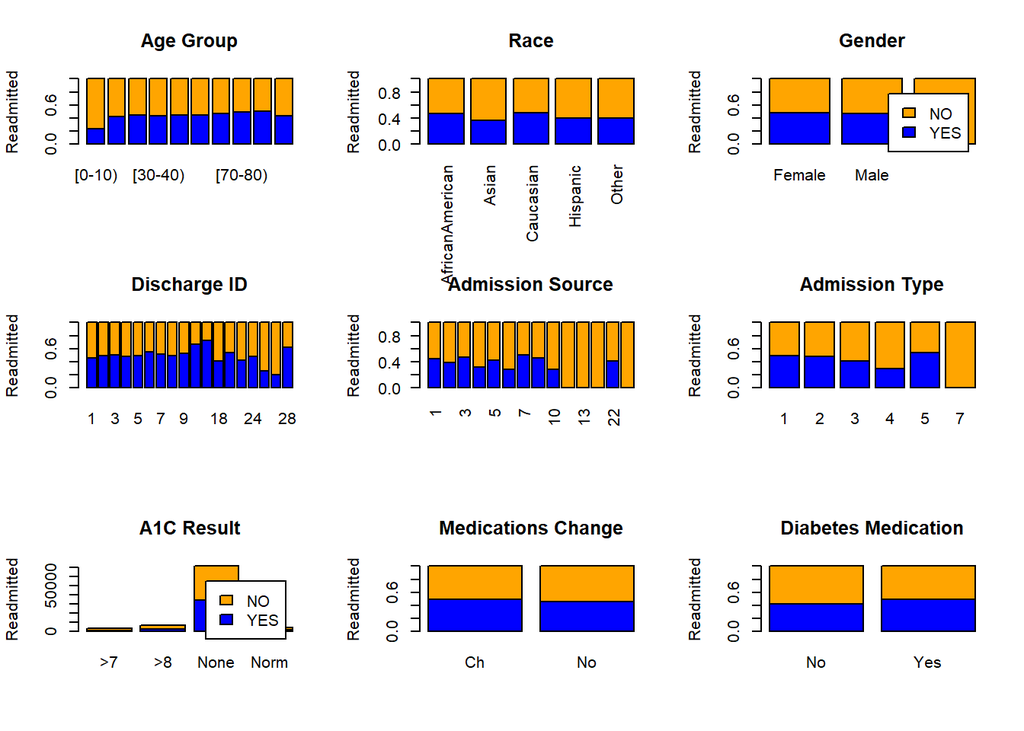

```r
## Create barplots ##
# Patient Demographics (Legend removed for individual graphs where bars would be blocked)
par(mfrow=c(3,3))
barplot(ct_age1,main="Age Group", ylab="Readmitted",col=c("blue", "orange"))
barplot(ct_race1,main="Race", ylab="Readmitted",col=c("blue", "orange"),las=2)
barplot(ct_gender1,main="Gender", ylab="Readmitted",col=c("blue", "orange"),
        legend=rownames(ct_gender1))

barplot(ct_dischargeID1,main="Discharge ID", ylab="Readmitted",col=c("blue", "orange"))
barplot(ct_admissionSource1,main="Admission Source",
        ylab="Readmitted",col=c("blue", "orange"),las=2)
barplot(ct_admissionType1,main="Admission Type", ylab="Readmitted",col=c("blue", "orange"))


barplot(ct_A1C,main="A1C Result", ylab="Readmitted",col=c("blue", "orange"),legend=rownames(ct_A1C))
barplot(ct_change1,main="Medications Change", ylab="Readmitted",col=c("blue", "orange"))
barplot(ct_diabMeds1,main="Diabetes Medication",ylab="Readmitted",col=c("blue", "orange"))
```

### 3. Data Preprocessing

#### **3.1 Select features**

- From EDA, we observe that variables number_emergency, number_outpatient, number_inpatient, A1Cresult, glyburide, pioglitazone, pioglitazone, rosiglitazone, glipizide show low variance or are extremely skewed. They will be excluded from modeling.

```r
df <- subset(df, select = -c(number_emergency, number_outpatient, number_inpatient, A1Cresult, glyburide, pioglitazone, pioglitazone, rosiglitazone, glipizide))

dim(df)
```

```
## [1] 86566    19
```

- After this step, 19 variables are left for modeling.

#### **3.2 Remove outliers**

```r
# Remove outlier from column 'num_lab_procedures'
quartiles <- quantile(df$num_lab_procedures, probs=c(.25, .75), na.rm = FALSE)
IQR <- IQR(df$num_lab_procedures)
Lower <- quartiles[1] - 1.5*IQR
Upper <- quartiles[2] + 1.5*IQR

count_before <-dim(df)[1]
df<- subset(df, df$num_lab_procedures > Lower & df$num_lab_procedures < Upper)
count_after <-dim(df)[1]
cat(count_before-count_after, " outliers in num_lab_procedures have been removed. \n")
```

```
## 186  outliers in num_lab_procedures have been removed.
```

```r
# Remove outliers from column 'number_diagnoses'
quartiles <- quantile(df$number_diagnoses, probs=c(.25, .75), na.rm = FALSE)
IQR <- IQR(df$number_diagnoses)
Lower <- quartiles[1] - 1.5*IQR
Upper <- quartiles[2] + 1.5*IQR

count_before <-dim(df)[1]
df <- subset(df, df$number_diagnoses > Lower & df$number_diagnoses < Upper)
count_after <-dim(df)[1]
cat(count_before-count_after, " outliers in number_diagnoses have been removed. \n")
```

```
## 52  outliers in number_diagnoses have been removed.
```

```r
# Remove outliers from column 'num_medications'
quartiles <- quantile(df$num_medications, probs=c(.25, .75), na.rm = FALSE)
IQR <- IQR(df$num_medications)
Lower <- quartiles[1] - 2*IQR
Upper <- quartiles[2] + 2*IQR

count_before <-dim(df)[1]
df <- subset(df, df$num_medications > Lower & df$num_medications < Upper)
count_after <-dim(df)[1]
cat(count_before-count_after, " outliers in num_medications have been removed. \n")
```

```
## 1287  outliers in num_medications have been removed.
```

#### **3.3 Partition data into training and test datasets using a 70% ratio**

- readmitted is the predicted variable. It will be separated from the predictors.

```r
#Separate X and Y using readmitted as predicted variable
dfX <- subset(df, select = -c(readmitted))
dfY <- subset(df, select = c(readmitted))

set.seed(123)
# Partition the dataset
trainRows <- createDataPartition(dfY$readmitted, p = .70, list = FALSE)

trainX <- dfX[trainRows,]
testX <-  dfX[-trainRows,]

trainY <- dfY[trainRows,]
testY <- dfY[-trainRows,]

dim(trainX)
```

```
## [1] 59529    18
```

```r
dim(testX)
```

```
## [1] 25512    18
```

- After the partition, there are 59529 instances in the training set and 25512 instances in the test set.

#### **3.4 Trandform and standardize features: center and scale**

```r
# center and scale the training set
train_tran <- preProcess(trainX, method=c("center", "scale"))
trainX <- predict(train_tran, trainX)

# center and scale the test set
testX <- predict(train_tran, testX)
```

#### **3.5 Convert categorical variables to dummy variables**

- Backup the training and testing sets before adding dummy variables for training different models

```r
library(fastDummies)

# Some models do not require dummy variable, like the trees
# Will use the sets without dummies for models
trainX_noDummy <- trainX
testX_noDummy <- testX

colnames(trainX_noDummy)
```

```
##  [1] "race"                     "gender"
##  [3] "age"                      "admission_type_id"
##  [5] "discharge_disposition_id" "admission_source_id"
##  [7] "time_in_hospital"         "num_lab_procedures"
##  [9] "num_procedures"           "num_medications"
## [11] "number_diagnoses"         "metformin"
## [13] "insulin"                  "change"
## [15] "diabetesMed"              "primary_diagnosis"
## [17] "secondary_diagnosis"      "secondary_diagnosis2"
```

- Categorical variables will now be converted into n-1 dummy variables.

```r
# Add dummy variables
trainX <- dummy_cols(trainX,
                     select_columns=c("race", "gender","age",
                                      "admission_type_id", "discharge_disposition_id","metformin",
                                      "insulin", "change","diabetesMed",
                                      "admission_source_id","primary_diagnosis",
                                      "secondary_diagnosis", "secondary_diagnosis2"),
                     remove_first_dummy=TRUE,
                     remove_selected_columns=TRUE)

testX <- dummy_cols(testX,
                     select_columns=c("race", "gender","age",
                                      "admission_type_id", "discharge_disposition_id","metformin",
                                      "insulin", "change","diabetesMed",
                                      "admission_source_id","primary_diagnosis",
                                      "secondary_diagnosis", "secondary_diagnosis2"),
                     remove_first_dummy=TRUE,
                     remove_selected_columns=TRUE)
```

#### **3.6 PCA Analysis**

- This is a high-dimensional dataset, we want to see if PCA can be applied to reduce feature dimension.

```r
# Find the PCA from the training set
pca <- prcomp(trainX)
pca_var <- pca$sdev^2

# Find the percentage of each PCA component
pca_percents <- pca_var / sum(pca_var)
cat("Percentage of the first 15 PCAs: ", pca_percents[1:15], "\n")
```

```
## Percentage of the first 15 PCAs:  0.1910663 0.1092462 0.08477103 0.06680895 0.06017332 0.04253663 0.03169632 0.02533176 0.02446798 0.02444144 0.02292527 0.02127575 0.02083785 0.01934805 0.01887004
```

```r
# The total percentage of the first 35 PCAs
cat("The total percentage of the first 35 PCAs: ", sum(pca_percents[1:35]), "\n")
```

```
## The total percentage of the first 35 PCAs:  0.9428998
```

- We see there are no dominant PCA components. The first 35 components represent 94% of the features.

### 4. Modeling

#### **4.0 Define functions**

First we will define a function to calculate the metrics of a trained model

```r
# Define a function to calculate the metrics of a trained model
get_training_metrics <- function(model, roc) {

  # Total number of training objects
  total <- dim(trainX)[1]

 # Construct model's confusion matrix
  cm <- confusionMatrix(model, norm = "none")

  # Calculate metrics
  accuracy <- round((cm$table[1,1] + cm$table[2,2]) / total, 3)
  sensitivity <- round(cm$table[1,1] / (cm$table[1,1] + cm$table[2,1]), 3)
  specificity <- round(cm$table[2,2] / (cm$table[2,2] + cm$table[1,2]), 3)
  precision <- round(cm$table[1,1] / (cm$table[1,1] + cm$table[1,2]), 3)
  recall <- sensitivity
  F1 <- round(2 * recall * precision / (recall + precision ), 3)

  # Return a vector of metrics
  c(accuracy, sensitivity, specificity, precision, recall, F1, round(roc,3))
}
```

Next we will define a function to calculate the metrics of prediction result on test dataset

```r
# Define a function to calculate the metrics of a trained model
get_test_metrics <- function(test_results) {
  total <- dim(testX)[1]

  # Construct prediction's confusion matrix
  cm <- confusionMatrix(test_results, testY, positive = "YES")

  # Calculate metrics
  accuracy <- round((cm$table[1,1] + cm$table[2,2]) / total, 3)
  sensitivity <- round(cm$table[1,1] / (cm$table[1,1] + cm$table[2,1]), 3)
  specificity <- round(cm$table[2,2] / (cm$table[2,2] + cm$table[1,2]), 3)
  precision <- round(cm$table[1,1] / (cm$table[1,1] + cm$table[1,2]), 3)
  recall <- sensitivity
  F1 <- round(2 * recall * precision / (recall + precision ), 3)
  # Return a vector of metrics
  c(accuracy, sensitivity, specificity, precision, recall, F1)
}
```

#### **4.1 Logistic Regression Model**

- First we will define a control variable that will be used to train all the models.
- We will use a 10 fold cross-validation method to optimize the training process.
- For each model, we will first train the model using training dataset, then use test dataset to test the model.
- We will generate a data frame to hold the training and testing performance metrics.

```r
# Define train control
ctrl <- trainControl(method = "cv", summaryFunction = twoClassSummary,
                     classProbs = TRUE, savePredictions = "final")

# Logistic Regression
set.seed(123)
lrFit <- train(x = trainX, y = trainY,
               method = "glm", metric = "ROC", trControl = ctrl)

# Calculate training/resampling performance metrics
metrics_tr <- data.frame(Metric.Train = c("Accuracy", "Sensitivity", "Specificity", "Precision", "Recall", "F-Measure", "ROC"))

metrics_tr$LR <- get_training_metrics(lrFit, lrFit$results$ROC)

#metrics_tr

# Predict on test data
lrTestResults <- predict(lrFit, testX)

# Calculate test performance metrics
metrics_test <- data.frame(Metric.Test = c("Accuracy", "Sensitivity", "Specificity", "Precision", "Recall", "F-Measure"))
metrics_test$LR <- get_test_metrics(lrTestResults)

# Importance of the predictors
lrImp <- varImp(lrFit, scale = FALSE)

# Display model's performance
metrics_tr[, c("Metric.Train", "LR")]
```

```
##   Metric.Train    LR
## 1     Accuracy 0.585
## 2  Sensitivity 0.524
## 3  Specificity 0.640
## 4    Precision 0.570
## 5       Recall 0.524
## 6    F-Measure 0.546
## 7          ROC 0.617
```

```r
metrics_test[, c("Metric.Test", "LR")]
```

```
##   Metric.Test    LR
## 1    Accuracy 0.586
## 2 Sensitivity 0.524
## 3 Specificity 0.643
## 4   Precision 0.572
## 5      Recall 0.524
## 6   F-Measure 0.547
```

- The training (cross validation) performance and testing performance for logistic regression model is displayed in the above metrics.

#### **4.2 Penalized Logistic Regression Model**

For penalized logistic regression model, we use the following perimeters to build the tuning grid:

- alpha values: 0, 0,0.1,0.2,0.4
- regularization perimeter lambda takes 5 values evenly between 0.01 and 0.1
- length: 5

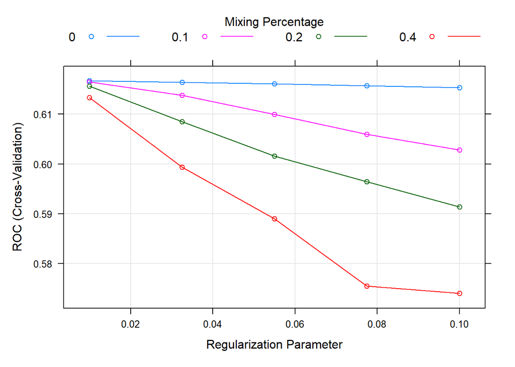

```r
# Penalized Logistic Regression
set.seed(123)
glmnGrid <- expand.grid(alpha=c(0,0.1,0.2,0.4),
                        lambda=seq(.01, .1, length=5))
glmnFit <- train(x = trainX, y = trainY,
                 method="glmnet", tuneGrid=glmnGrid,
                 metric="ROC", trControl=ctrl)
#glmnFit

# Calculate training/resampling performance metrics
metrics_tr$GLMN <- get_training_metrics(glmnFit, glmnFit$results$ROC[1])
#metrics_tr

# Predict on test data
glmnTestResults <- predict(glmnFit, testX)

# Calculate test performance metrics
metrics_test$GLMN <- get_test_metrics(glmnTestResults)

# Importance of the predictors
glmnImp <- varImp(glmnFit, scale = FALSE)


# Plot the tuning results
plot(glmnFit)
```

```r
# Display model's performance
metrics_tr[, c("Metric.Train", "GLMN")]
```

```
##   Metric.Train  GLMN
## 1     Accuracy 0.585
## 2  Sensitivity 0.521
## 3  Specificity 0.642
## 4    Precision 0.570
## 5       Recall 0.521
## 6    F-Measure 0.544
## 7          ROC 0.617
```

```r
metrics_test[, c("Metric.Test", "GLMN")]
```

```
##   Metric.Test  GLMN
## 1    Accuracy 0.586
## 2 Sensitivity 0.520
## 3 Specificity 0.646
## 4   Precision 0.572
## 5      Recall 0.520
## 6   F-Measure 0.545
```

- The cross validation result shows the optimal model comes when alpha=0, lambda=0.01
- The training (cross validation) performance and testing performance is displayed in the above metrics.

#### **4.3 Nearest Shrunken Centroids Model**

For Nearest Shrunken Centroids model, we use the following perimeter to build the tuning grid:

- threshold takes 20 values evenly spaced between 0 and 15

```r
# Nearest Shrunken Centroids
set.seed(123)
nscFit <- train(x=trainX,y=trainY,
                method="pam", tuneGrid=data.frame(threshold=seq(0,15, length=20)),
                metric="ROC", trControl=ctrl)
```

```
## 11111111111
```

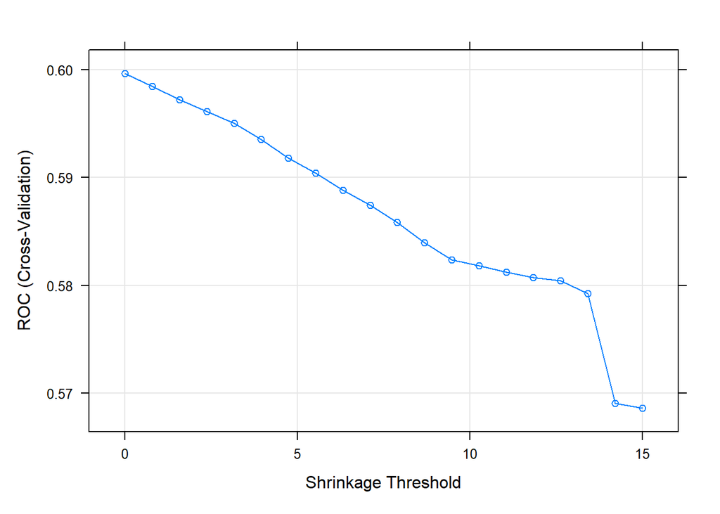

```r
#nscFit

# Calculate training/resampling performance metrics
metrics_tr$NSC <- get_training_metrics(nscFit, nscFit$results$ROC[1])

# Predict on test data
nscTestResults <- predict(nscFit, testX)

# Calculate test performance metrics
metrics_test$NSC <- get_test_metrics(nscTestResults)

# Importance of the predictors
nscImp <- varImp(nscFit, scale = FALSE)

# Plot the tuning result
plot(nscFit)
```

```r
# Display model's performance
metrics_tr[, c("Metric.Train", "NSC")]
```

```
##   Metric.Train   NSC
## 1     Accuracy 0.570
## 2  Sensitivity 0.504
## 3  Specificity 0.629
## 4    Precision 0.553
## 5       Recall 0.504
## 6    F-Measure 0.527
## 7          ROC 0.600
```

```r
metrics_test[, c("Metric.Test", "NSC")]
```

```
##   Metric.Test   NSC
## 1    Accuracy 0.575
## 2 Sensitivity 0.507
## 3 Specificity 0.637
## 4   Precision 0.559
## 5      Recall 0.507
## 6   F-Measure 0.532
```

- The cross validation result shows the optimal model comes when shrinkage threshhold is 0.
- The training (cross validation) performance and testing performance is displayed in the above metrics.

#### **4.4 Boosted Trees**

For the boosted trees model, we use the following perimeter to build the tuning grid:

- interaction depth: 5, 7
- number of trees: 500
- shrinkage: 0.01, 0.1

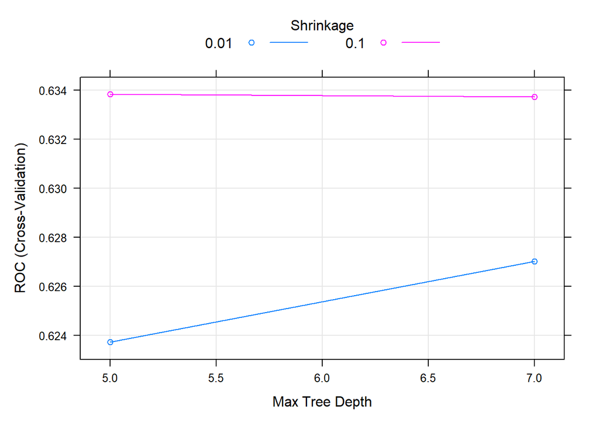

```r
gbmGrid <- expand.grid(interaction.depth = c(5, 7),
                       n.trees = 500,
                       shrinkage = c(.01, .1),
                       n.minobsinnode = 5)

set.seed(123)

gbmFit <- train(x = trainX_noDummy, y = trainY,
                method = "gbm", tuneGrid = gbmGrid,
                verbose = FALSE, metric = "ROC", trControl = ctrl)

# Calculate training/resampling performance metrics
metrics_tr$GBM <- get_training_metrics(gbmFit, gbmFit$results$ROC[3])
#metrics_tr

# Predict on test data
gbmTestResults <- predict(gbmFit, testX_noDummy)

# Calculate test performance metrics
metrics_test$GBM <- get_test_metrics(gbmTestResults)

#The tunning result
#gbmFit
plot(gbmFit)
```

```r
# Display model's performance
metrics_tr[, c("Metric.Train", "GBM")]
```

```
##   Metric.Train   GBM
## 1     Accuracy 0.596
## 2  Sensitivity 0.561
## 3  Specificity 0.628
## 4    Precision 0.578
## 5       Recall 0.561
## 6    F-Measure 0.569
## 7          ROC 0.627
```

```r
metrics_test[, c("Metric.Test", "GBM")]
```

```
##   Metric.Test   GBM
## 1    Accuracy 0.601
## 2 Sensitivity 0.565
## 3 Specificity 0.633
## 4   Precision 0.583
## 5      Recall 0.565
## 6   F-Measure 0.574
```

- The cross validation result shows the optimal model comes when shrinkage is 0.1 and depth is 5..
- The training (cross validation) performance and testing performance is displayed in the above metrics.

#### **4.5 Bagged Tree**

For bagged tree model, we use the following perimeter to train:

- number of bag(nbagg) = 30

```r
set.seed(123)

trbagFit <- train(x = trainX_noDummy, y = trainY,
                method = "treebag",
                nbagg = 30,
                metric = "ROC",
                trControl = ctrl)

#trbagFit

# Calculate training/resampling performance metrics
metrics_tr$TRBAG <- get_training_metrics(trbagFit, trbagFit$results$ROC)

# Predict on test data
trbagTestResults <- predict(trbagFit, testX_noDummy)

# Calculate test performance metrics
metrics_test$TRBAG <- get_test_metrics(trbagTestResults)

# Display model's performance
metrics_tr[, c("Metric.Train", "TRBAG")]
```

```
##   Metric.Train TRBAG
## 1     Accuracy 0.572
## 2  Sensitivity 0.541
## 3  Specificity 0.601
## 4    Precision 0.552
## 5       Recall 0.541
## 6    F-Measure 0.546
## 7          ROC 0.603
```

```r
metrics_test[, c("Metric.Test", "TRBAG")]
```

```
##   Metric.Test TRBAG
## 1    Accuracy 0.569
## 2 Sensitivity 0.535
## 3 Specificity 0.601
## 4   Precision 0.549
## 5      Recall 0.535
## 6   F-Measure 0.542
```

- The training (cross validation) performance and testing performance is displayed in the above metrics.

#### **4.6 Random Forest Tree**

For random forest tree model, we use the following perimeter to build the tuning grid:

- number of randomly selected predictors: 1, 3, 5, 7
- number of trees: 100

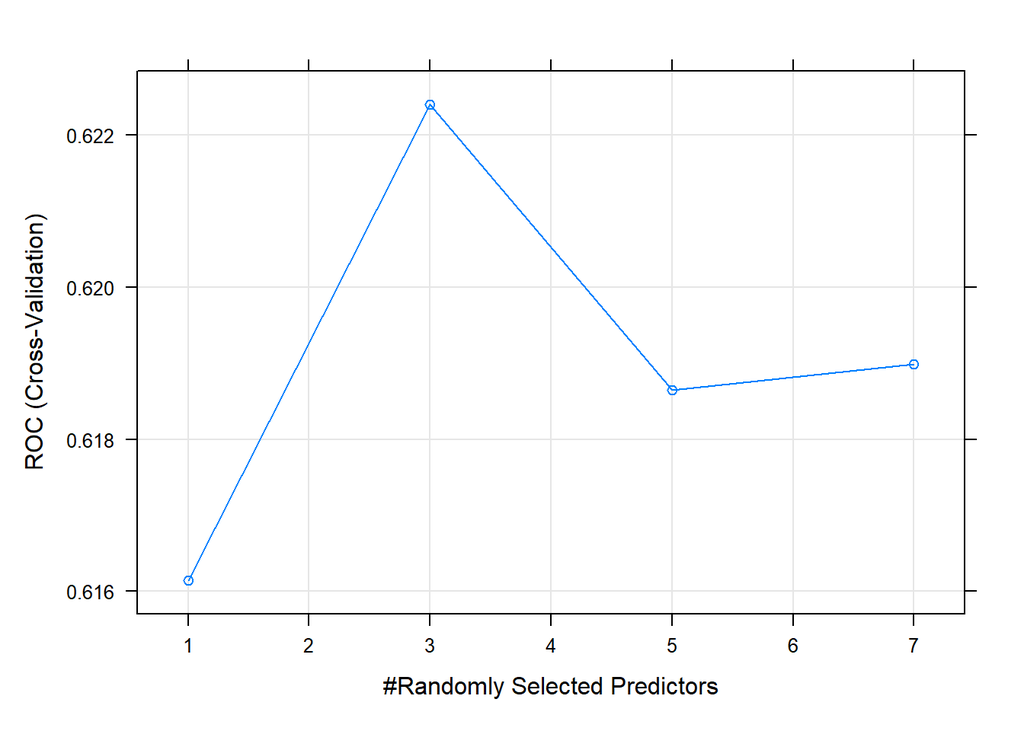

```r
mtryValues <- seq(1,8,2)

set.seed(123)
rfFit <- train(x = trainX_noDummy, y = trainY,
                method = "rf",
                ntree = 100,
                tuneGrid = data.frame(mtry = mtryValues),
                metric = "ROC",
                trControl = ctrl)


# Calculate training/resampling performance metrics
metrics_tr$RF <- get_training_metrics(rfFit, rfFit$results$ROC[2])

# Predict on test data
rfTestResults <- predict(rfFit, testX_noDummy)

# Calculate test performance metrics
metrics_test$RF <- get_test_metrics(rfTestResults)

# Importance of the predictors
rfImp <- varImp(rfFit, scale = FALSE)

# Plot tuning result
#rfFit
plot(rfFit)
```

```r
# Display model's performance
metrics_tr[, c("Metric.Train", "RF")]
```

```
##   Metric.Train    RF
## 1     Accuracy 0.586
## 2  Sensitivity 0.532
## 3  Specificity 0.635
## 4    Precision 0.570
## 5       Recall 0.532
## 6    F-Measure 0.550
## 7          ROC 0.622
```

```r
metrics_test[, c("Metric.Test", "RF")]
```

```
##   Metric.Test    RF
## 1    Accuracy 0.587
## 2 Sensitivity 0.503
## 3 Specificity 0.663
## 4   Precision 0.576
## 5      Recall 0.503
## 6   F-Measure 0.537
```

- The cross validation result shows the optimal model comes when the number of randomly selected predictors is 3
- The training (cross validation) performance and testing performance is displayed in the above metrics.

#### **4.7 K-Nearest Neighbor (KNN) Model**

For KNN model, we use the following perimeter to build the tuning grid:

- tuneLength = 3
- number of neighbors: 5, 7, 9

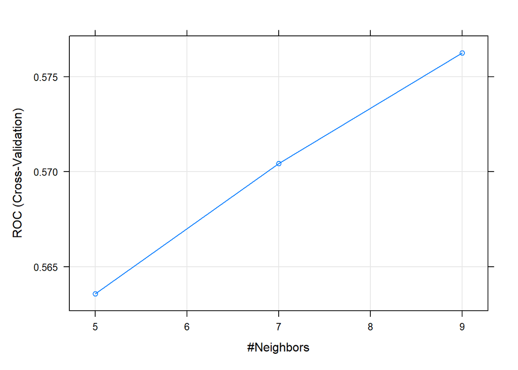

```r
set.seed(123)

knnFit <- train(x = trainX, y = trainY,
                 method = "knn",
                 tuneLength = 3,
                 metric = "ROC", trControl = ctrl)


# Calculate training/resampling performance metrics
metrics_tr$KNN <- get_training_metrics(knnFit, knnFit$results$ROC[3])

# Predict on test data
knnTestResults <- predict(knnFit, testX)

# Calculate test performance metrics
metrics_test$KNN <- get_test_metrics(knnTestResults)

# Importance of the predictors
knnImp <- varImp(knnFit, scale = FALSE)

# Plot the tuning results
#knnFit
plot(knnFit)
```

```r
# Display model's performance
metrics_tr[, c("Metric.Train", "KNN")]
```

```
##   Metric.Train   KNN
## 1     Accuracy 0.555
## 2  Sensitivity 0.527
## 3  Specificity 0.581
## 4    Precision 0.534
## 5       Recall 0.527
## 6    F-Measure 0.530
## 7          ROC 0.576
```

```r
metrics_test[, c("Metric.Test", "KNN")]
```

```
##   Metric.Test   KNN
## 1    Accuracy 0.557
## 2 Sensitivity 0.528
## 3 Specificity 0.583
## 4   Precision 0.535
## 5      Recall 0.528
## 6   F-Measure 0.531
```

- The cross validation result shows the optimal model comes when K is 9.
- The training (cross validation) performance and testing performance is displayed in the above metrics.

### 5. Model Evaluation and Conclusion

#### **5.1 Baseline Model**

- For this data analysis, a model’s ability to predict the positive (readmitted-Yes) accurately is the most important metric. Therefore, we choose All Positive Model as the base model.

```r
round(table(trainY) / length(trainY), 3)
```

```
## trainY
##   YES    NO
## 0.476 0.524
```

- From the above table, we see that when we assign all predictions as positive, the accuracy of this base model is 0.476

#### **5.2 Calculate AUC (Area Under ROC Curve)**

For each model, based on the trained models’ result, we first generate ROC, then calculate the area under ROC curve (AUC)

```r
#ROC Curve
library(pROC)
lrROC <- roc(response=trainY,predictor=lrFit$pred$YES,levels=rev(levels(lrFit$pred$obs)))
glmnROC <- roc(response=trainY,predictor=glmnFit$pred$YES,levels=rev(levels(glmnFit$pred$obs)))
nscROC <- roc(response=trainY,predictor=nscFit$pred$YES,levels=rev(levels(nscFit$pred$obs)))
gbmROC <- roc(response=trainY,predictor=gbmFit$pred$YES,levels=rev(levels(gbmFit$pred$obs)))
rfROC <- roc(response=trainY,predictor=rfFit$pred$YES,levels=rev(levels(rfFit$pred$obs)))
trbagROC <- roc(response=trainY,predictor=trbagFit$pred$YES,levels=rev(levels(trbagFit$pred$obs)))
knnROC <- roc(response=trainY,predictor=knnFit$pred$YES,levels=rev(levels(knnFit$pred$obs)))

lrAUC <-round(auc(lrROC), 3)
glmnAUC <-round(auc(glmnROC), 3)
nscAUC <-round(auc(nscROC), 3)
gbmAUC <-round(auc(gbmROC), 3)
rfAUC <-round(auc(rfROC), 3)
trbagAUC <-round(auc(trbagROC), 3)
knnAUC <-round(auc(knnROC), 3)

# Get Area under the ROC
metrics_tr <- rbind(metrics_tr, c("AUC", lrAUC, glmnAUC, nscAUC,
                                  gbmAUC, rfAUC, trbagAUC, knnAUC))
```

- The AUC values are added to the training model’s performance metrics data frame.

#### **5.3 Compare models’ performance metrics**

- Compare Models’ training (cross-validation) performance

```r
metrics_tr
```

```
##   Metric.Train    LR  GLMN   NSC   GBM TRBAG    RF   KNN
## 1     Accuracy 0.585 0.585  0.57 0.596 0.572 0.586 0.555
## 2  Sensitivity 0.524 0.521 0.504 0.561 0.541 0.532 0.527
## 3  Specificity  0.64 0.642 0.629 0.628 0.601 0.635 0.581
## 4    Precision  0.57  0.57 0.553 0.578 0.552  0.57 0.534
## 5       Recall 0.524 0.521 0.504 0.561 0.541 0.532 0.527
## 6    F-Measure 0.546 0.544 0.527 0.569 0.546  0.55  0.53
## 7          ROC 0.617 0.617   0.6 0.627 0.603 0.622 0.576
## 8          AUC 0.503  0.51 0.502 0.502 0.499 0.503 0.495
```

- Compare Models’ test performance

```r
metrics_test
```

```
##   Metric.Test    LR  GLMN   NSC   GBM TRBAG    RF   KNN
## 1    Accuracy 0.586 0.586 0.575 0.601 0.569 0.587 0.557
## 2 Sensitivity 0.524 0.520 0.507 0.565 0.535 0.503 0.528
## 3 Specificity 0.643 0.646 0.637 0.633 0.601 0.663 0.583
## 4   Precision 0.572 0.572 0.559 0.583 0.549 0.576 0.535
## 5      Recall 0.524 0.520 0.507 0.565 0.535 0.503 0.528
## 6   F-Measure 0.547 0.545 0.532 0.574 0.542 0.537 0.531
```

#### **5.4 Plot Roc Curves**

- We plot the ROC curves for all trainings models in one graph. The comparison can be seen with different marking colors.

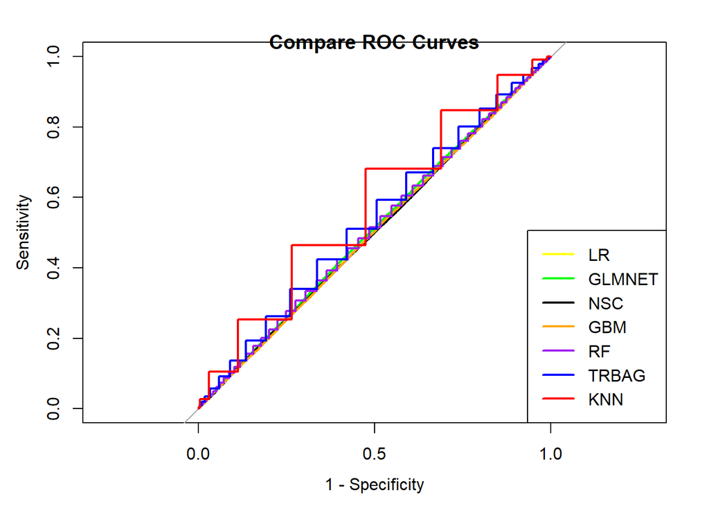

```r
plot(lrROC, type="s", col='yellow', legacy.axes=TRUE)
plot(glmnROC, type="s", add=TRUE, col='green', legacy.axes=TRUE)
plot(nscROC, type="s", add=TRUE, col='black', legacy.axes=TRUE)
plot(gbmROC, type="s", add=TRUE, col='orange',legacy.axes=TRUE)
plot(rfROC, type="s", add=TRUE, col='purple', legacy.axes=TRUE)
plot(trbagROC, type="s", add=TRUE, col='blue',legacy.axes=TRUE)
plot(knnROC, type="s", add=TRUE, col='red', legacy.axes=TRUE)

legend("bottomright", legend=c("LR", "GLMNET", "NSC", "GBM", "RF", "TRBAG", "KNN"),
       col=c("yellow","green", "black",'orange', 'purple','blue', 'red'), lwd=2)


title(main="Compare ROC Curves")
```

#### **5.5 Check Feature’s Importance**

- We displayed the first 15 important features from logistic regression model, random forest model, and KNN model respectively.

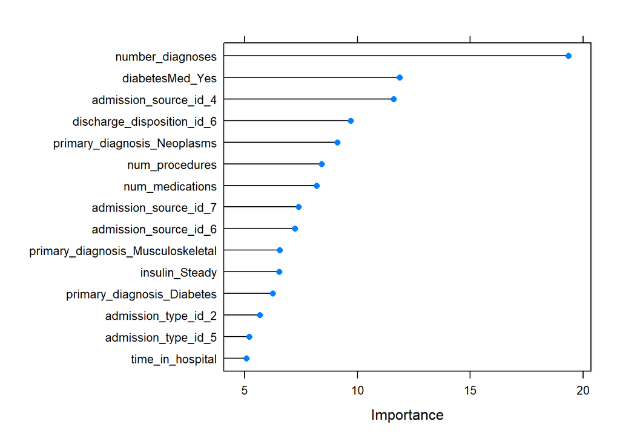

```r
plot(lrImp, top = 15)
```

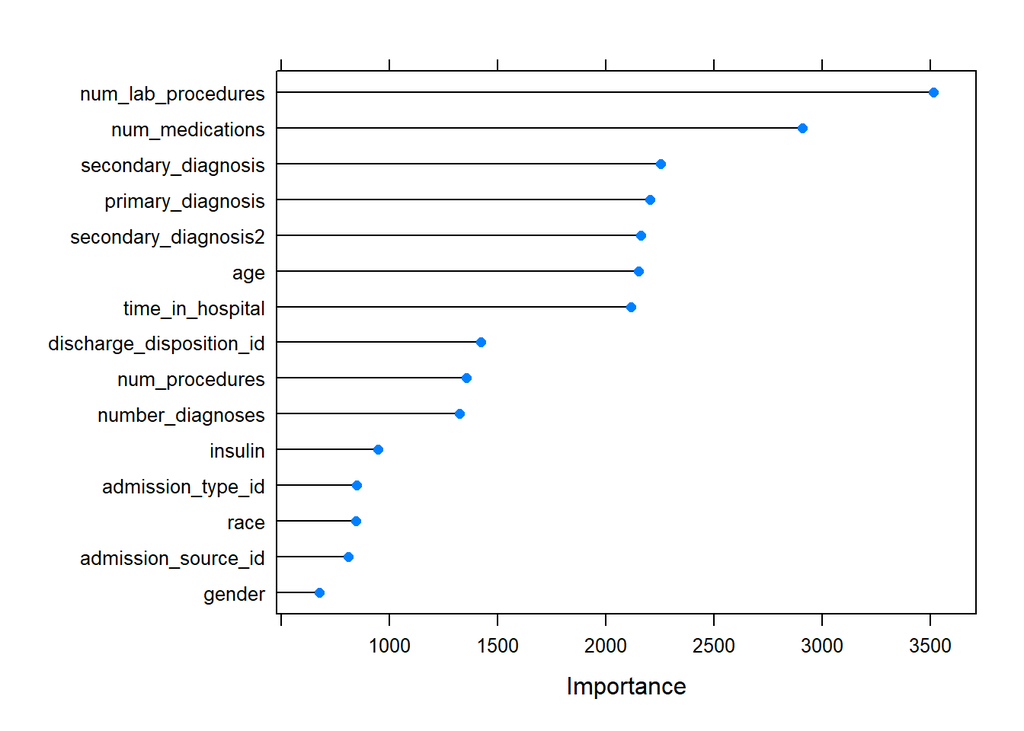

```r
plot(rfImp, top = 15)
```

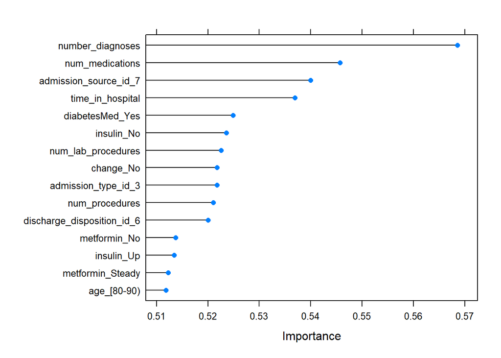

```r
plot(knnImp, top = 15)
```

- Though each model displays the important features in different order, some features appear commonly in the top list.
- These important features include: number_diagnoses, num_procedures, num_lab_procedures, num_medication, time_in_hospital. etc.